# Reading and plotting deconvolution results

Chananchida Sang-aram

2026-06-13

```r
library(tidyverse)
library(Seurat)
```

```r
source("utils/scatterbarplot_function.R")
```

The `runRCTD.R` script returns two files: * `*_proportions.tsv` contains the bin-by-cell type proportions * `*_doublet_info.tsv` contains information about the confidence of the predictions, i.e., “singlet”, “doublet_certain”, “doublet_uncertain”, and “reject”.

Let’s read in both of them.

```r
doublet_info <- read.table("tutorial/example_data/rctd_doublet_info.tsv",
                          header = TRUE)
head(doublet_info)
```

```
##                    spot        spot_class   first_type   second_type
## 1 s_016um_00105_00280-1   doublet_certain  01IT-ETGlut 07CTX-MGEGABA
## 2 s_016um_00111_00289-1 doublet_uncertain  01IT-ETGlut    33Vascular
## 3 s_016um_00099_00285-1   doublet_certain  01IT-ETGlut  30Astro-Epen
## 4 s_016um_00106_00286-1   doublet_certain 30Astro-Epen   01IT-ETGlut
## 5 s_016um_00109_00283-1   doublet_certain  01IT-ETGlut  30Astro-Epen
## 6 s_016um_00102_00278-1   doublet_certain  01IT-ETGlut  30Astro-Epen
##   first_class second_class min_score singlet_score conv_all conv_doublet
## 1       FALSE        FALSE  497.6869      525.9764     TRUE         TRUE
## 2       FALSE        FALSE  974.7655     1014.7238     TRUE         TRUE
## 3       FALSE        FALSE  647.9860      719.4519     TRUE         TRUE
## 4       FALSE        FALSE  586.5705      719.0157     TRUE         TRUE
## 5       FALSE        FALSE  789.1143      829.6190     TRUE         TRUE
## 6       FALSE        FALSE  708.2247      793.5705     TRUE         TRUE
```

```r
proportions <- read.table("tutorial/example_data/rctd_proportions.tsv",
                          row.names = 1, header = TRUE)
head(proportions)
```

```
##                       X01IT.ETGlut X07CTX.MGEGABA X33Vascular X30Astro.Epen
## s_016um_00105_00280-1    0.5652399      0.4347601  0.00000000     0.0000000
## s_016um_00111_00289-1    0.9020876      0.0000000  0.09791245     0.0000000
## s_016um_00099_00285-1    0.8413422      0.0000000  0.00000000     0.1586578
## s_016um_00106_00286-1    0.5390428      0.0000000  0.00000000     0.4609572
## s_016um_00109_00283-1    0.8893553      0.0000000  0.00000000     0.1106447
## s_016um_00102_00278-1    0.8234426      0.0000000  0.00000000     0.1765574
##                       X34Immune X02NP.CT.L6bGlut X06CTX.CGEGABA
## s_016um_00105_00280-1         0                0              0
## s_016um_00111_00289-1         0                0              0
## s_016um_00099_00285-1         0                0              0
## s_016um_00106_00286-1         0                0              0
## s_016um_00109_00283-1         0                0              0
## s_016um_00102_00278-1         0                0              0
```

Let’s load the original Visium HD object and visualize the deconvolution results spatially, as shown in our paper. In this visualization, each bin is represented by a bar plot showing the predicted cell type proportions. The plotting function is provided in `utils/scatterbarplot_function.R`, where all function parameters are documented.

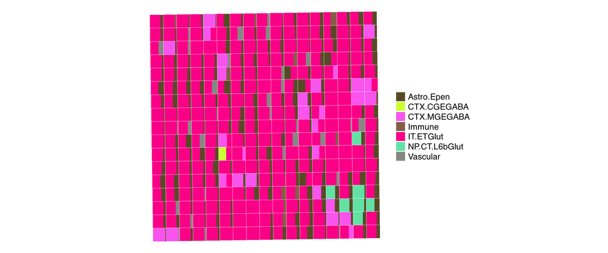

```r
visium_obj_roi <- readRDS("tutorial/example_data/Visium_HD_MouseBrain_016um_6951x289.rds")
square_size <- visium_obj_roi@images[["slice1.016um"]]@scale.factors$spot

# Clean up colnames
colnames(proportions) <- gsub("X[0-9]+", "", colnames(proportions))

# Color palette from ABA
color_palette <- c("IT.ETGlut" = "#FA0087",
                   "NP.CT.L6bGlut" = "#61e2a4",
                   "CTX.CGEGABA" = "#CCFF33",
                   "CTX.MGEGABA" = "#f954ee",
                   "Astro.Epen" = "#594a26",
                   "Vascular" =  "#858881",
                   "Immune" = "#825f45" )

plot_scatterbar(deconv_props = proportions,
                square_size = square_size,
                visium_obj_roi = visium_obj_roi,
                color_palette = color_palette) +
  theme(legend.text = element_text(size=12),
        legend.key.size = unit(0.5, "cm"))
```

### Extra: using the scatterbarplot function on the full dataset

The example dataset covers only a small region of the tissue. When working with a complete Visium HD dataset, it is usually more visually appealing to subset the data before visualization. As an example, we will use the mouse brain FFPE dataset at 8µm resolution. The Seurat object and deconvolved proportions for the are available on [Zenodo](https://zenodo.org/records/20716044) under `full_data.zip`.

```r
visium_obj <- readRDS("tutorial/full_data/Visium_HD_MouseBrain_008um.rds")
visium_obj
```

```
## An object of class Seurat
## 19059 features across 393543 samples within 1 assay
## Active assay: Spatial.008um (19059 features, 0 variable features)
##  1 layer present: counts
##  1 spatial field of view present: slice1.008um
```

```r
brain_props <-  read.table("tutorial/full_data/mousebrain_ffpe_8um_proportions.tsv",
                          row.names = 1, header = TRUE)
head(brain_props)
```

```
##                       X18THGlut X16HYMMGlut X19MBGlut X01IT.ETGlut
## s_008um_00301_00321-1         1   0.0000000 0.0000000    0.0000000
## s_008um_00515_00112-1         0   0.3051241 0.6948759    0.0000000
## s_008um_00383_00696-1         0   0.0000000 0.0000000    0.8226312
## s_008um_00526_00291-1         0   0.0000000 0.0000000    0.0000000
## s_008um_00078_00444-1         0   0.0000000 0.0000000    1.0000000
## s_008um_00123_00164-1         0   0.0000000 0.0000000    0.0000000
##                       X30Astro.Epen X27MYGABA X02NP.CT.L6bGlut X31OPC.Oligo
## s_008um_00301_00321-1     0.0000000         0                0            0
## s_008um_00515_00112-1     0.0000000         0                0            0
## s_008um_00383_00696-1     0.1773688         0                0            0
## s_008um_00526_00291-1     0.0000000         1                0            0
## s_008um_00078_00444-1     0.0000000         0                0            0
## s_008um_00123_00164-1     0.0000000         0                1            0
##                       X13CNU.HYaGlut X07CTX.MGEGABA X04DG.IMNGlut X33Vascular
## s_008um_00301_00321-1              0              0             0           0
## s_008um_00515_00112-1              0              0             0           0
## s_008um_00383_00696-1              0              0             0           0
## s_008um_00526_00291-1              0              0             0           0
## s_008um_00078_00444-1              0              0             0           0
## s_008um_00123_00164-1              0              0             0           0
##                       X28CBGABA X10LSXGABA X14HYGlut X24MYGlut X15HYGnrh1Glut
## s_008um_00301_00321-1         0          0         0         0              0
## s_008um_00515_00112-1         0          0         0         0              0
## s_008um_00383_00696-1         0          0         0         0              0
## s_008um_00526_00291-1         0          0         0         0              0
## s_008um_00078_00444-1         0          0         0         0              0
## s_008um_00123_00164-1         0          0         0         0              0
##                       X23PGlut X17MH.LHGlut X09CNU.LGEGABA X34Immune
## s_008um_00301_00321-1        0            0              0         0
## s_008um_00515_00112-1        0            0              0         0
## s_008um_00383_00696-1        0            0              0         0
## s_008um_00526_00291-1        0            0              0         0
## s_008um_00078_00444-1        0            0              0         0
## s_008um_00123_00164-1        0            0              0         0
##                       X08CNU.MGEGABA X20MBGABA X06CTX.CGEGABA X11CNU.HYaGABA
## s_008um_00301_00321-1              0         0              0              0
## s_008um_00515_00112-1              0         0              0              0
## s_008um_00383_00696-1              0         0              0              0
## s_008um_00526_00291-1              0         0              0              0
## s_008um_00078_00444-1              0         0              0              0
## s_008um_00123_00164-1              0         0              0              0
##                       X32OEC X25PinealGlut X12HYGABA X26PGABA X21MBDopa
## s_008um_00301_00321-1      0             0         0        0         0
## s_008um_00515_00112-1      0             0         0        0         0
## s_008um_00383_00696-1      0             0         0        0         0
## s_008um_00526_00291-1      0             0         0        0         0
## s_008um_00078_00444-1      0             0         0        0         0
## s_008um_00123_00164-1      0             0         0        0         0
##                       X22MB.HBSero X05OB.IMNGABA X03OB.CRGlut X29CBGlut
## s_008um_00301_00321-1            0             0            0         0
## s_008um_00515_00112-1            0             0            0         0
## s_008um_00383_00696-1            0             0            0         0
## s_008um_00526_00291-1            0             0            0         0
## s_008um_00078_00444-1            0             0            0         0
## s_008um_00123_00164-1            0             0            0         0
```

We can subset the Visium HD to a region of interest (ROI) by specifying ranges of x and y coordinates. Note, however, that in the output of `Seurat::GetTissueCoordinates()`, the x coordinate corresponds to the image row index and therefore maps to the y-axis in standard Cartesian coordinates. In addition, In addition, coordinate values increase from top to bottom, rather than from bottom to top as in Cartesian plots.

[figure not shown]

```r
roi <- c(row_start = 6000,
         row_end = 7000,
         col_start = 4000,
         col_end = 5000)

# Visualize cells in ROI
cells_roi <- GetTissueCoordinates(visium_obj) %>%
  filter(x > roi["row_start"] & x < roi["row_end"] &
         y > roi["col_start"] & y < roi["col_end"]) %>%
  pull(cell)

SpatialDimPlot(visium_obj,
               cells.highlight = cells_roi)
```

```r
# Subset data
visium_obj_subset <- visium_obj[,Cells(visium_obj) %in% cells_roi]
```

Once the ROI has been selected, the scatterbarplot can be generated as before. The function will automatically subset the proportions table to include only bins present in the ROI Visium HD object.

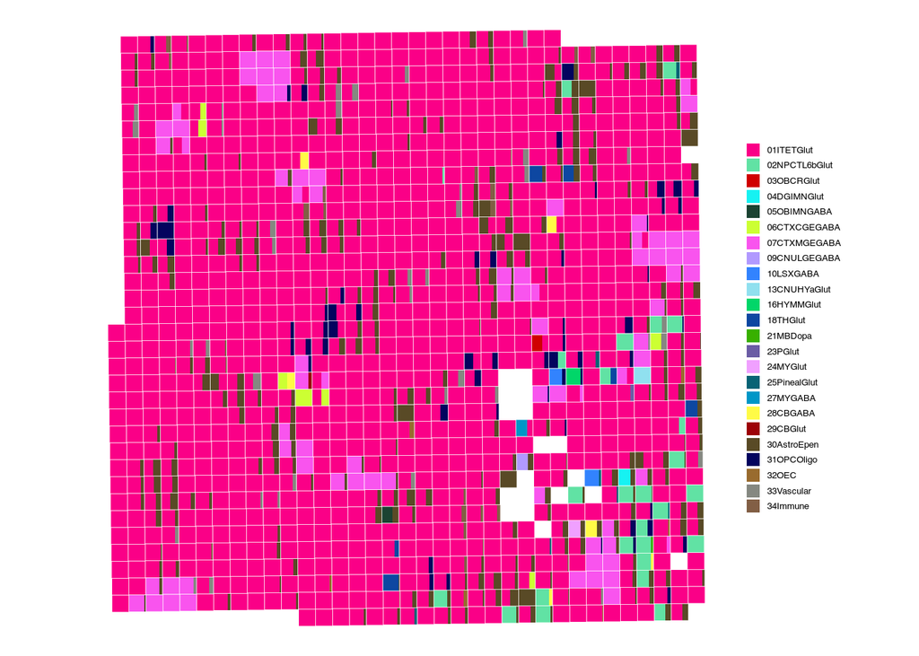

```r
square_size <- visium_obj@images[["slice1.008um"]]@scale.factors$spot

celltype_colors <- read.csv("tutorial/full_data/celltype_colors.csv")
celltype_colors <- celltype_colors$class_color %>% setNames(celltype_colors$class)
colnames(brain_props) <- gsub("^X|\\.", "", colnames(brain_props))

plot_scatterbar(deconv_props = brain_props,
                square_size = square_size,
                visium_obj_roi = visium_obj_subset,
                color_palette = celltype_colors)
```